# Data Science II - Assignment

Phong Duong - 100500507

# Problem description

In our cities, there are some services that are essential for our daily living: **pharmacies, schools or transport points of sale.** However, these facilities are not necessarily well distributed. We want to analyze in this assignment which areas lacks of these facilities based on regression models. The steps to perform the analysis are:

- Do a descriptive analysis of data
- Are there variables we can discard?
- Perform a feature engineering process extending important variables.
- Perform regression modelling for the three target variables (three different models).
- Create a score to measure **which areas** have enough facilities and which ones don’t.
- Which variables are the most highly related to the score? In particular, what makes a census section to have a low number of facilities?
- Visualize and discuss the results

# Dataset description

```r
df<-fread("census_section_stats.csv", sep=";", dec=",", stringsAsFactors = F)
head(df)
```

```
##    index census_section_code census_district_code city_code province_code
## 1:     0          2807915077              2807915     28079            28
## 2:     1          2807911153              2807911     28079            28
## 3:     2          2807912045              2807912     28079            28
## 4:     3          2807912028              2807912     28079            28
## 5:     4          2807912037              2807912     28079            28
## 6:     5          2807912008              2807912     28079            28
##          area                                     centroid population
## 1: 0.03106851 POINT (445950.10837580997 4475766.441625915)       1073
## 2: 0.03689683  POINT (435897.6843577322 4468991.370699024)       1578
## 3: 0.03168443 POINT (440254.6396935178 4470484.3928486835)       1793
## 4: 0.01147211 POINT (441426.03395814047 4469702.549072934)        911
## 5: 0.04474097  POINT (441515.5287670559 4468906.541133046)       1324
## 6: 0.04552570   POINT (439391.811371995 4469340.731671609)       1226
##    family_income income_per_capita  avg_age   spanish foreigners   europeans
```

[output cut: 83 more lines]

For every census section we have a row in our dataset, here are some of the main columns of the dataset: * census_section_code: census_section_code identifier * n_pharmacies (target variable 1): number of pharmacies in the census section * n_schools (target variable 2): number of schools in the census section * n_transport_salespoints: number of transport points of sale.

# Descriptive analysis

## Data Exploration

### Brief Check of overall data

```r
str(df)
```

```
## Classes 'data.table' and 'data.frame':   4414 obs. of  65 variables:
##  $ index                        : int  0 1 2 3 4 5 6 7 8 9 ...
##  $ census_section_code          :integer64 2807915077 2807911153 2807912045 2807912028 2807912037 2807912008 2807911155 2807911191 ...
##  $ census_district_code         : int  2807915 2807911 2807912 2807912 2807912 2807912 2807911 2807911 2807908 2807908 ...
##  $ city_code                    : int  28079 28079 28079 28079 28079 28079 28079 28079 28079 28079 ...
##  $ province_code                : int  28 28 28 28 28 28 28 28 28 28 ...
##  $ area                         : num  0.0311 0.0369 0.0317 0.0115 0.0447 ...
##  $ centroid                     : chr  "POINT (445950.10837580997 4475766.441625915)" "POINT (435897.6843577322 4468991.370699024)" "POINT (440254.6396935178 4470484.3928486835)" "POINT (441426.03395814047 4469702.549072934)" ...
##  $ population                   : int  1073 1578 1793 911 1324 1226 2392 2250 817 997 ...
##  $ family_income                : num  31418 26574 22959 22828 23078 ...
##  $ income_per_capita            : num  12899 10194 7426 9018 8403 ...
##  $ avg_age                      : num  49 44.1 38.7 46.1 43.3 ...
##  $ spanish                      : num  0.866 0.776 0.627 0.786 0.918 ...
##  $ foreigners                   : num  0.1342 0.2237 0.3731 0.2141 0.0816 ...
##  $ europeans                    : num  0.0317 0.0786 0.0167 0.056 0.0068 ...
```

[output cut: 52 more lines]

```r
summary(df)
```

```
##      index      census_section_code  census_district_code   city_code
##  Min.   :   0   Min.   :2800101001   Min.   :2800101      Min.   :28001
##  1st Qu.:1103   1st Qu.:2807901027   1st Qu.:2807901      1st Qu.:28079
##  Median :2206   Median :2807910084   Median :2807910      Median :28079
##  Mean   :2206   Mean   :2808267820   Mean   :2808268      Mean   :28083
##  3rd Qu.:3310   3rd Qu.:2807918047   3rd Qu.:2807918      3rd Qu.:28079
##  Max.   :4413   Max.   :2890301025   Max.   :2890301      Max.   :28903
##  province_code      area             centroid           population
##  Min.   :28    Min.   :  0.00594   Length:4414        Min.   :  47
##  1st Qu.:28    1st Qu.:  0.02962   Class :character   1st Qu.:1075
##  Median :28    Median :  0.05510   Mode  :character   Median :1381
##  Mean   :28    Mean   :  1.81802                      Mean   :1490
##  3rd Qu.:28    3rd Qu.:  0.17587                      3rd Qu.:1816
##  Max.   :28    Max.   :180.87857                      Max.   :4004
##  family_income   income_per_capita    avg_age         spanish
##  Min.   :12537   Min.   : 3719     Min.   :25.54   Min.   :0.5293
##  1st Qu.:27843   1st Qu.:10580     1st Qu.:40.26   1st Qu.:0.8267
##  Median :34315   Median :13046     Median :43.48   Median :0.8870
##  Mean   :39489   Mean   :14798     Mean   :42.81   Mean   :0.8723
##  3rd Qu.:45429   3rd Qu.:17523     3rd Qu.:46.11   3rd Qu.:0.9316
##  Max.   :91933   Max.   :32242     Max.   :65.80   Max.   :1.0000
##    foreigners        europeans          germans            bulgarian
##  Min.   :0.00000   Min.   :0.00000   Min.   :0.0000000   Min.   :0.000000
##  1st Qu.:0.06844   1st Qu.:0.02225   1st Qu.:0.0000000   1st Qu.:0.000000
##  Median :0.11302   Median :0.03463   Median :0.0005139   Median :0.001415
##  Mean   :0.12773   Mean   :0.04296   Mean   :0.0011480   Mean   :0.003190
##  3rd Qu.:0.17327   3rd Qu.:0.05170   3rd Qu.:0.0014967   3rd Qu.:0.004183
##  Max.   :0.47070   Max.   :0.37260   Max.   :0.0425532   Max.   :0.071467
##      french            italian             polish           portuguese
##  Min.   :0.000000   Min.   :0.000000   Min.   :0.000000   Min.   :0.0000000
##  1st Qu.:0.000000   1st Qu.:0.001131   1st Qu.:0.000000   1st Qu.:0.0004852
##  Median :0.000800   Median :0.002936   Median :0.001106   Median :0.0014996
##  Mean   :0.002043   Mean   :0.004480   Mean   :0.002248   Mean   :0.0022547
##  3rd Qu.:0.002249   3rd Qu.:0.005994   3rd Qu.:0.003012   3rd Qu.:0.0032338
##  Max.   :0.121133   Max.   :0.037788   Max.   :0.134831   Max.   :0.0243902
##     british             romanian        non_european         russian
##  Min.   :0.0000000   Min.   :0.00000   Min.   :0.000000   Min.   :0.0000000
##  1st Qu.:0.0000000   1st Qu.:0.00525   1st Qu.:0.001590   1st Qu.:0.0000000
##  Median :0.0006845   Median :0.01401   Median :0.003870   Median :0.0000000
##  Mean   :0.0014827   Mean   :0.02417   Mean   :0.005906   Mean   :0.0006801
```

[output cut: 64 more lines]

```
##  Max.   :100.000          Max.   :99.366                Max.   :1433.0
##  city_population   population_density    geometry          n_pharmacies
##  Min.   :     47   Min.   :     1.06   Length:4414        Min.   :0.0000
##  1st Qu.: 128256   1st Qu.:  9194.66   Class :character   1st Qu.:0.0000
##  Median :3223334   Median : 24941.68   Mode  :character   Median :1.0000
##  Mean   :1832968   Mean   : 26806.53                      Mean   :0.6613
##  3rd Qu.:3223334   3rd Qu.: 41233.71                      3rd Qu.:1.0000
##  Max.   :3223334   Max.   :113560.50                      Max.   :5.0000
##    n_schools       n_transport_salespoints pcg_foreigners
##  Min.   : 0.0000   Min.   :0.0000          Min.   : 0.000
##  1st Qu.: 0.0000   1st Qu.:0.0000          1st Qu.: 6.844
##  Median : 0.0000   Median :0.0000          Median :11.302
##  Mean   : 0.9076   Mean   :0.2707          Mean   :12.773
##  3rd Qu.: 1.0000   3rd Qu.:0.0000          3rd Qu.:17.327
##  Max.   :12.0000   Max.   :4.0000          Max.   :47.070
```

No missing data (NA)

```r
#Convert to appropriate data type
df <- df %>%
  mutate(
    census_section_code = as.character(census_section_code),
    census_district_code = as.character(census_district_code),
    city_code = as.character(city_code),
    province_code = as.character(province_code)
  ) %>% #Extracting latitude and longitude from centroid
  mutate(centroid = str_extract_all(centroid, "\\d+.\\d+")) %>%
  unnest_wider(col = c(centroid), names_sep = "_") %>%
  rename(lat = centroid_1, long = centroid_2) %>%
  mutate(lat = as.numeric(lat), long = as.numeric(long))
```

### **Target variables**

```r
target_vars <- df %>%
  select(n_pharmacies, n_schools, n_transport_salespoints)

summary(target_vars)
```

```
##   n_pharmacies      n_schools       n_transport_salespoints
##  Min.   :0.0000   Min.   : 0.0000   Min.   :0.0000
##  1st Qu.:0.0000   1st Qu.: 0.0000   1st Qu.:0.0000
##  Median :1.0000   Median : 0.0000   Median :0.0000
##  Mean   :0.6613   Mean   : 0.9076   Mean   :0.2707
##  3rd Qu.:1.0000   3rd Qu.: 1.0000   3rd Qu.:0.0000
##  Max.   :5.0000   Max.   :12.0000   Max.   :4.0000
```

The average number of **pharmacies** in each census is 0.66 (median = 1) with range of 0 to 5. The average number of **schools** in each census is 0.91 (median = 0) and there are anywhere between 0 and 12 school in the censuses. The average number of number of **transport POS** is 0.27 (median = 0) and range from 0 to 4.

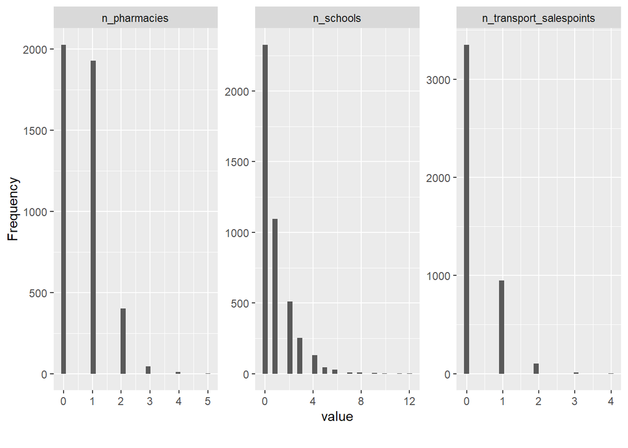

```r
plot_histogram(target_vars)
```

From the plots, we can see that most censuses have 0 to 2 pharmacies in the area, 0 to 4 schools, and 0 to 1 transport POS.

The graph strongly indicate that some censuses might be lacking facilities in their areas. We will continue to explore the data set to identify possible variables contributing to this lack of facilities.

It is also noted that all 3 graphs are skewed to the right, suggesting that the distribution of facilities are not normal. Since the variables are discreet and non-negative, a poisson regression might be a good fit for the model. We can check the first assumption (equidispersion) to see if it’s a potential fit.

```r
data.frame(
  mean = c(mean(df$n_pharmacies), mean(df$n_schools), mean(df$n_transport_salespoints)),
  var = c(var(df$n_pharmacies), var(df$n_schools), var(df$n_transport_salespoints)),
  row.names = c("pharmacy", "school", "transport")
)
```

```
##                mean       var
## pharmacy  0.6613049 0.5032066
## school    0.9075668 1.7970286
## transport 0.2707295 0.2654607
```

It seems that the target variables have similar mean and variance, this could indicate a call for poisson regression model. Although school has variance > mean, which is case of overdispersion, we can still use different methods to improve the model such as a Quasi-poisson Regression.

### Numerical Data

```r
df_num <- df %>%
  select(where(is.numeric)) %>%
  select(-index)
```

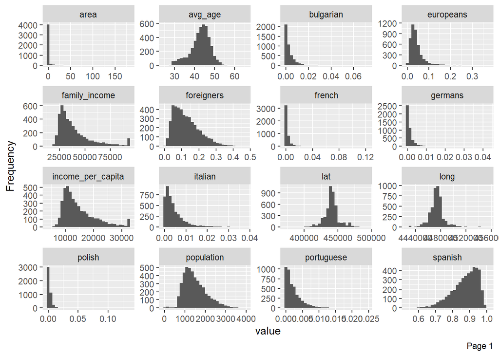

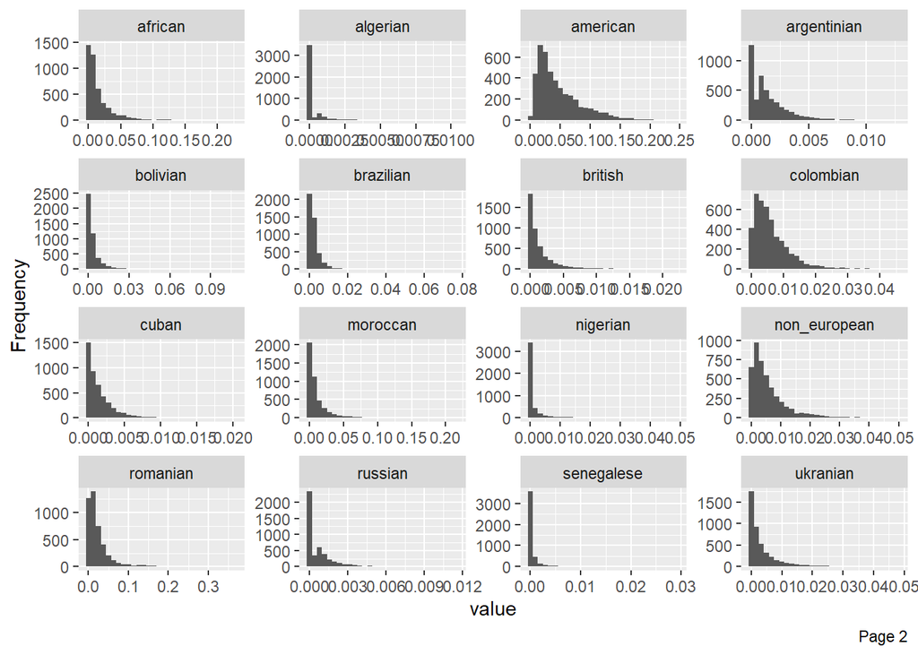

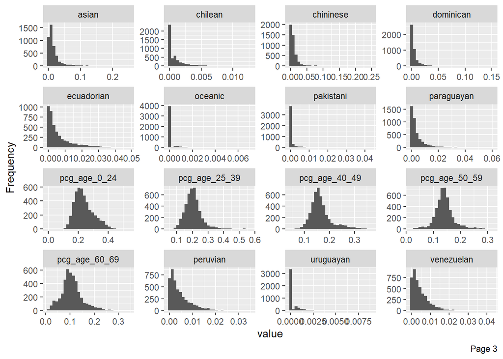

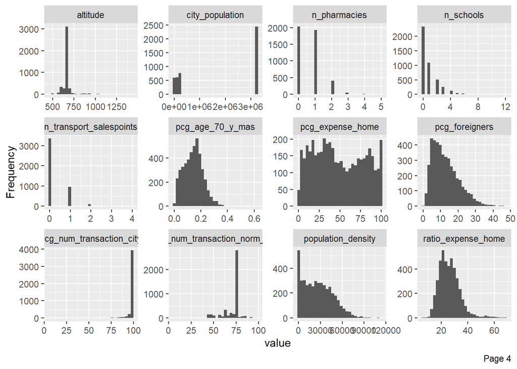

```r
#histogram
plot_histogram(df_num)
```

It is noted that different censuses seem to have different concentration of age, income, population, and foreigners - spaniards percentage. These might be important factors influencing the number of facilities in each census.

### Bivariate Analysis

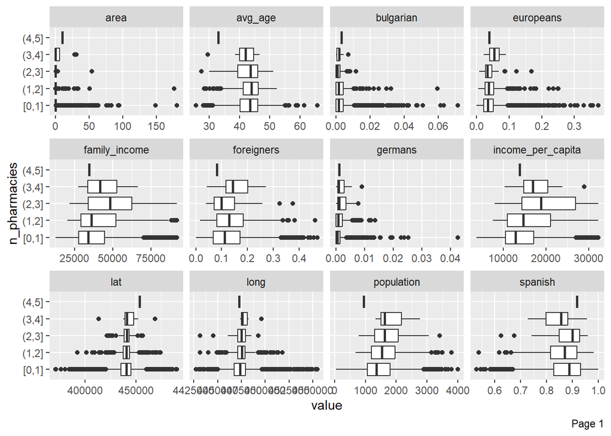

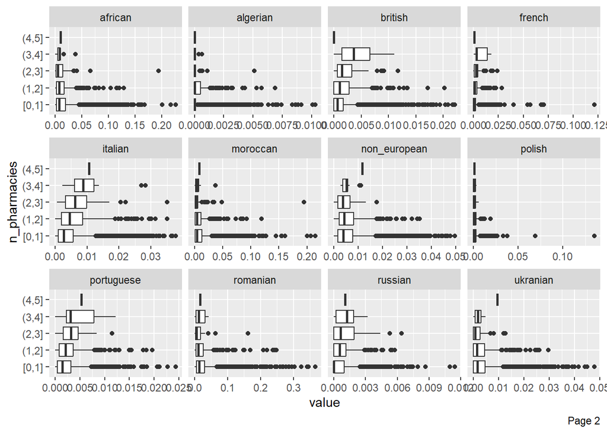

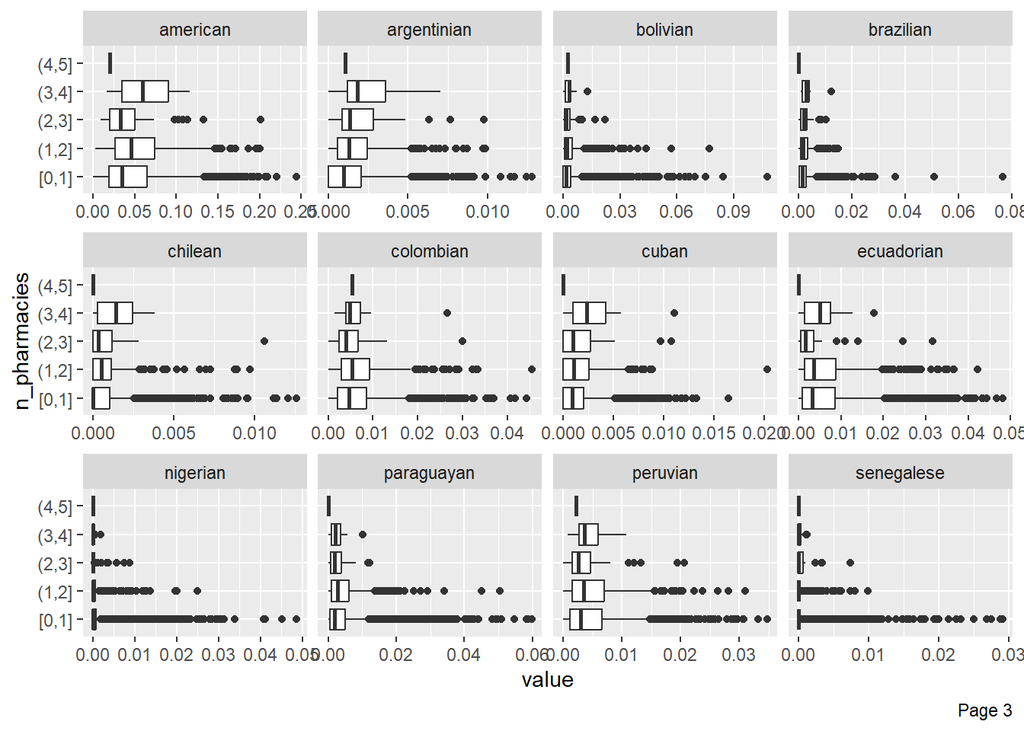

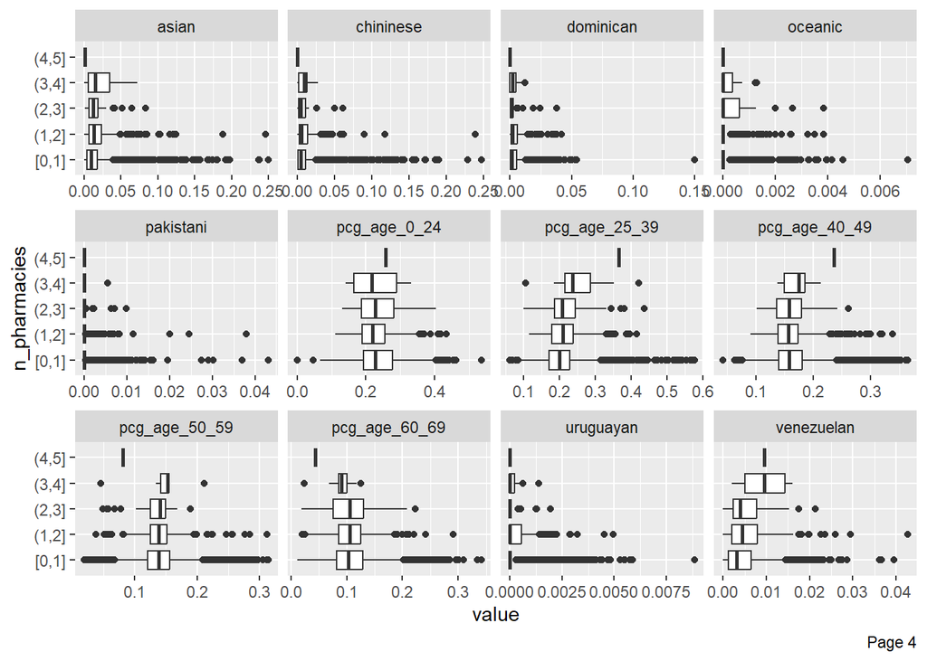

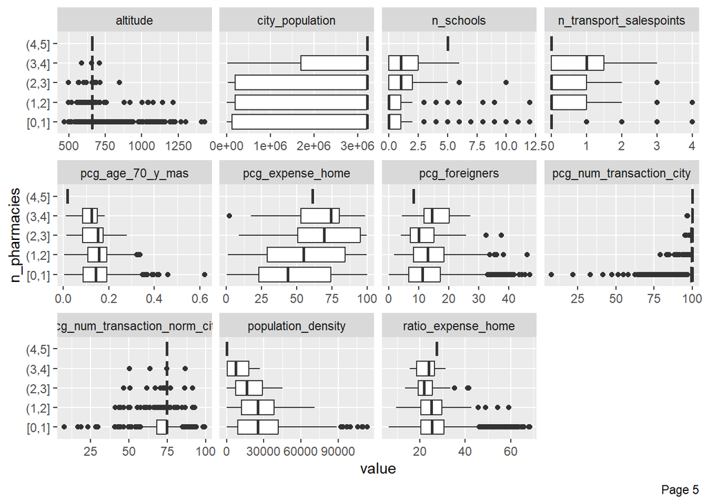

```r
plot_boxplot(df_num, by = "n_pharmacies")
```

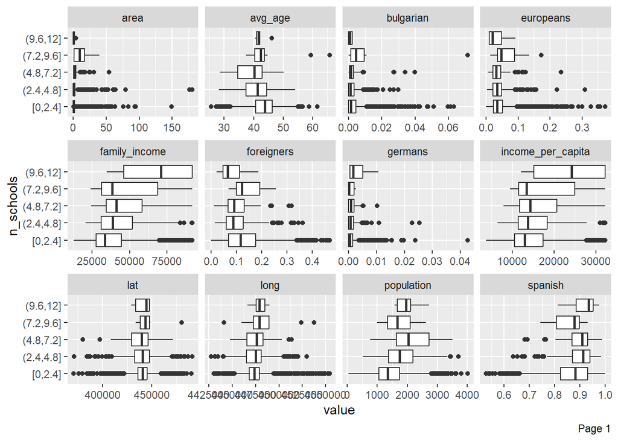

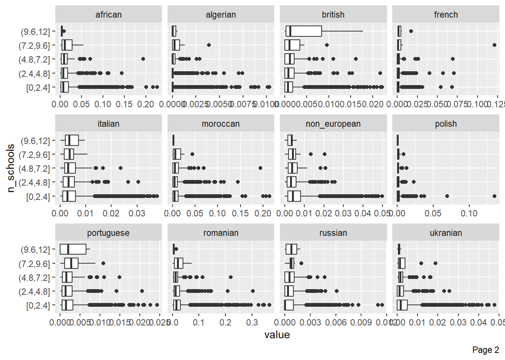

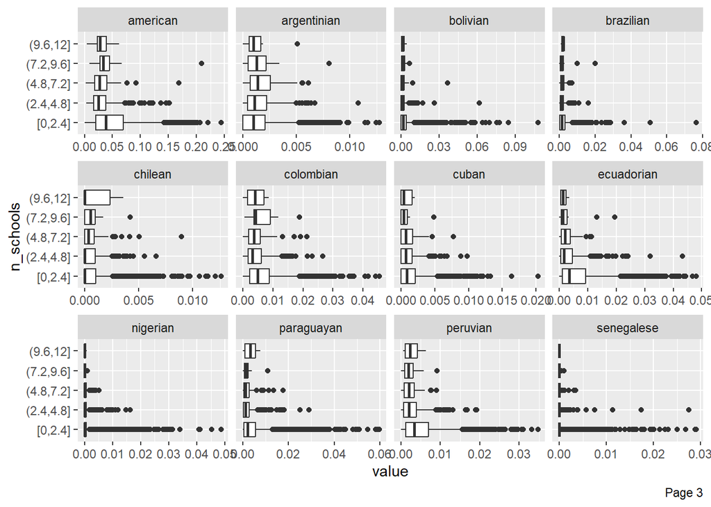

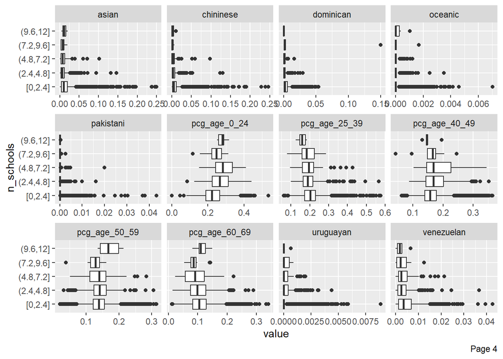

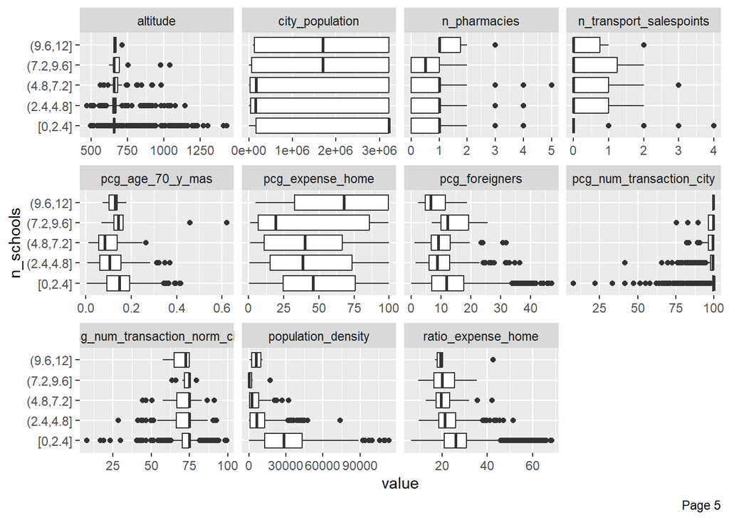

```r
plot_boxplot(df_num, by = "n_schools")
```

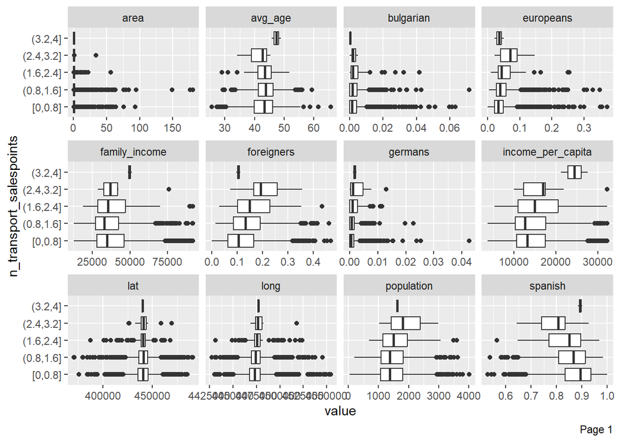

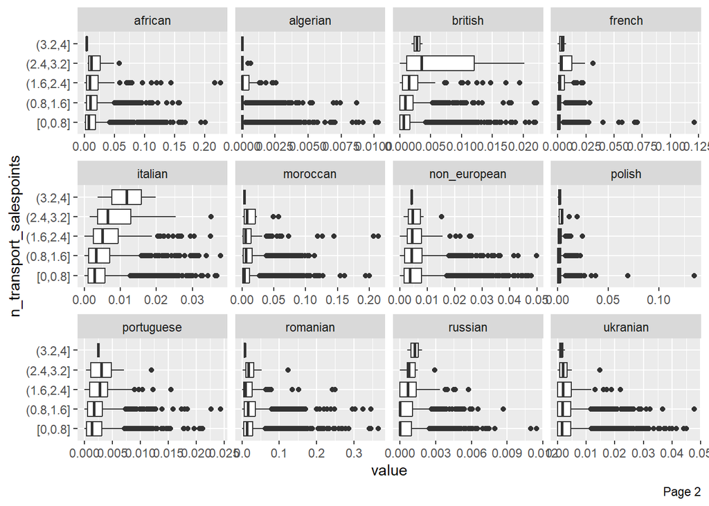

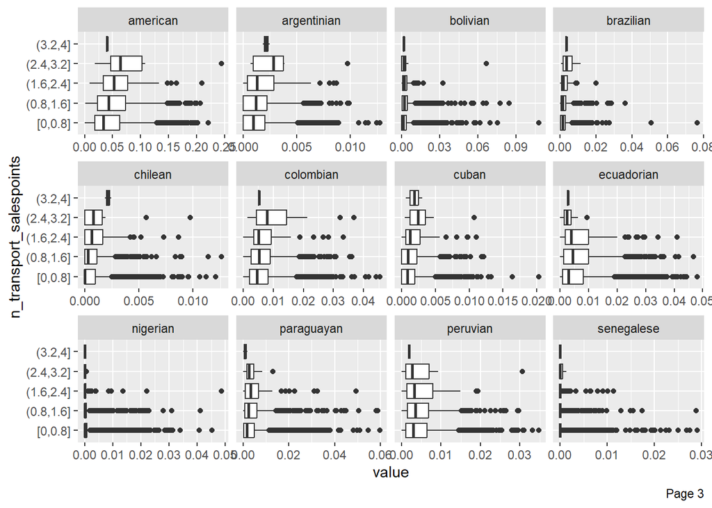

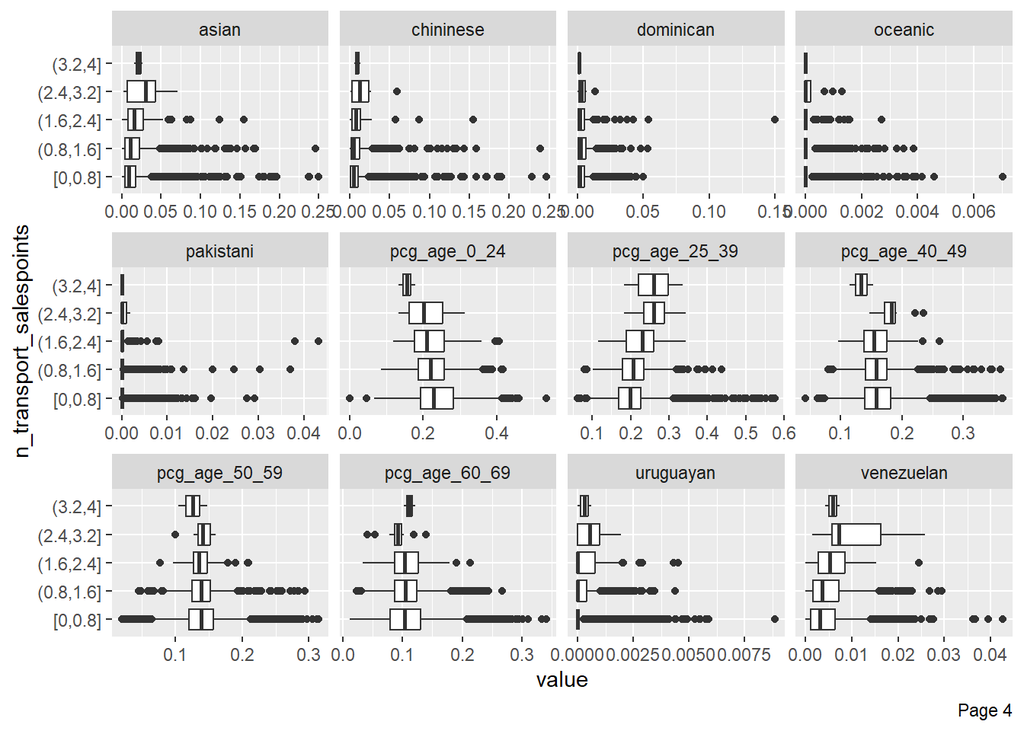

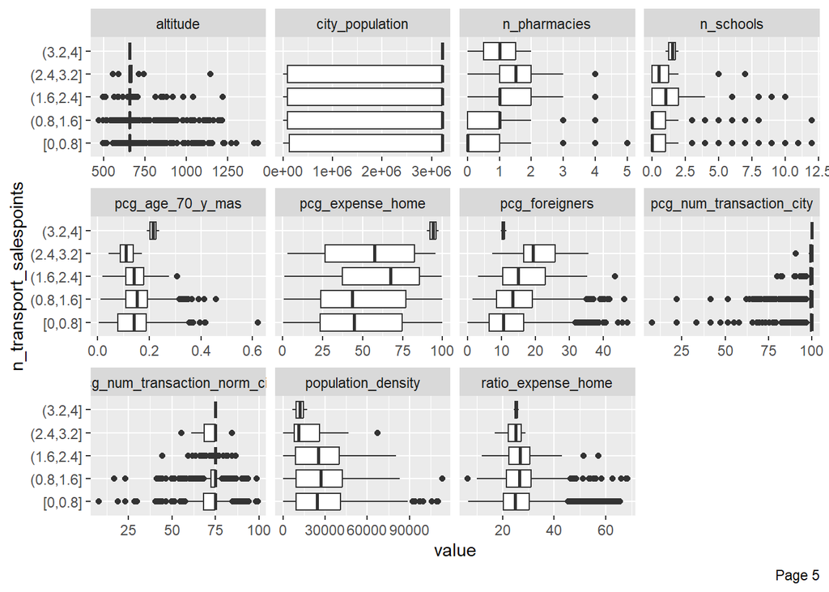

```r
plot_boxplot(df_num, by = "n_transport_salespoints")
```

With lots of predictors in the data set it is difficult to understand all of them and their relations to our response variables. We will instead check them with correlation analysis.

### Correlation Analysis

```r
#Correlation Matrix
cor_matrix <- cor(df_num)

findCorrelation(
  cor_matrix,
  cutoff = 0.6,
  verbose = T,
  names = T,
  exact = T
)
```

```
## Compare row 8  and column  9 with corr  1
##   Means:  0.295 vs 0.14 so flagging column 8
## Compare row 9  and column  60 with corr  1
##   Means:  0.283 vs 0.135 so flagging column 9
## Compare row 60  and column  27 with corr  0.75
##   Means:  0.27 vs 0.13 so flagging column 60
## Compare row 27  and column  34 with corr  0.782
##   Means:  0.244 vs 0.126 so flagging column 27
## Compare row 5  and column  6 with corr  0.937
##   Means:  0.224 vs 0.121 so flagging column 5
## Compare row 6  and column  50 with corr  0.672
##   Means:  0.212 vs 0.119 so flagging column 6
## Compare row 22  and column  24 with corr  0.946
##   Means:  0.156 vs 0.115 so flagging column 22
## Compare row 39  and column  40 with corr  0.823
##   Means:  0.156 vs 0.114 so flagging column 39
## Compare row 44  and column  49 with corr  0.738
##   Means:  0.169 vs 0.112 so flagging column 44
## Compare row 14  and column  17 with corr  0.615
##   Means:  0.156 vs 0.11 so flagging column 14
## Compare row 19  and column  21 with corr  0.918
##   Means:  0.131 vs 0.108 so flagging column 19
## Compare row 18  and column  10 with corr  0.91
##   Means:  0.125 vs 0.107 so flagging column 18
## Compare row 49  and column  7 with corr  0.908
##   Means:  0.132 vs 0.106 so flagging column 49
## Compare row 7  and column  48 with corr  0.622
##   Means:  0.115 vs 0.106 so flagging column 7
## Compare row 48  and column  46 with corr  0.693
##   Means:  0.098 vs 0.106 so flagging column 46
## Compare row 3  and column  54 with corr  0.643
##   Means:  0.102 vs 0.107 so flagging column 54
## All correlations <= 0.6
```

```
##  [1] "spanish"           "foreigners"        "pcg_foreigners"
##  [4] "american"          "family_income"     "income_per_capita"
##  [7] "african"           "asian"             "pcg_age_0_24"
## [10] "italian"           "non_european"      "romanian"
## [13] "pcg_age_70_y_mas"  "avg_age"           "pcg_age_40_49"
## [16] "altitude"
```

It seems that a couple of variables are correlated to each other, which might create a problem (multicolinearity) when we run the model so we should consider removing some of them for better model performance.

### Zero Variance Variables

```r
nearZeroVar(df, saveMetrics = TRUE) %>% filter(nzv == TRUE | zeroVar == TRUE)
```

```
##                          freqRatio percentUnique zeroVar  nzv
## province_code              0.00000    0.02265519    TRUE TRUE
## pcg_num_transaction_city  25.44792    4.48572723   FALSE TRUE
```

It seems that province code only has 1 value for all observations and pcg_num_transaction_city has a very low variance. We will check them to see if we should remove them since they might not offer much help to our model.

## Feature selection

#### Checking features with low variance and are duplicated

```r
df %>% distinct(province_code)
```

```
## # A tibble: 1 × 1
##   province_code
##   <chr>
## 1 28
```

Province_code also only has 1 observation, therefore, it will not be useful for the model.

```r
df %>% distinct(pcg_num_transaction_city)
```

```
## # A tibble: 207 × 1
##    pcg_num_transaction_city
##                       <dbl>
##  1                   100
##  2                    55.1
##  3                    99.5
##  4                    94.6
##  5                    98.4
##  6                    91.0
##  7                    88.6
##  8                    82.2
##  9                    51.7
## 10                     7.80
## # ℹ 197 more rows
```

pcg_num_transaction_city has some variation in values so we will keep it for now since our data set is also not too big.

```r
cor(df$foreigners, df$pcg_foreigners)
```

```
## [1] 1
```

#### Dimensionality Reduction

```r
set.seed(100507500)
elastic_p <- train(
  n_pharmacies ~., data = df_num, method = "glmnet",
  trControl = trainControl("cv", number = 10),
  tuneLength = 10
  )

#Columns with 0 coefs
coef0_p <- coef(elastic_p$finalModel, elastic_p$bestTune$lambda) %>%
  as.matrix() %>%
  data.frame() %>%
  filter(s1 == 0) %>%
  row.names()
coef0_p
```

```
##  [1] "lat"                "long"               "family_income"
##  [4] "avg_age"            "europeans"          "germans"
##  [7] "bulgarian"          "french"             "polish"
## [10] "romanian"           "russian"            "american"
## [13] "brazilian"          "chilean"            "ecuadorian"
## [16] "chininese"          "pcg_age_25_39"      "pcg_age_40_49"
## [19] "pcg_age_50_59"      "ratio_expense_home" "altitude"
```

```r
set.seed(100507500)
elastic_s <- train(
  n_schools ~., data = df_num, method = "glmnet",
  trControl = trainControl("cv", number = 10),
  tuneLength = 10
  )

coef0_s <- coef(elastic_s$finalModel, elastic_s$bestTune$lambda) %>%
  as.matrix() %>%
  data.frame() %>%
  filter(s1 == 0) %>%
  row.names()
```

```r
set.seed(100507500)
elastic_t <- train(
  n_transport_salespoints ~., data = df_num, method = "glmnet",
  trControl = trainControl("cv", number = 10),
  tuneLength = 10
  )
coef0_t <- coef(elastic_t$finalModel, elastic_t$bestTune$lambda) %>%
  as.matrix() %>%
  data.frame() %>%
  filter(s1 == 0) %>%
  row.names()
coef0_t
```

```
##  [1] "foreigners"    "french"        "ukranian"      "african"
##  [5] "bolivian"      "cuban"         "chilean"       "venezuelan"
##  [9] "asian"         "pcg_age_0_24"  "pcg_age_50_59"
```

#### Final Selection

```r
fs_p <- df_num %>% #Pharmacy
  select(-all_of(coef0_p))

fs_s <- df_num %>% #School
  select(-all_of(coef0_s))

fs_t <- df_num %>% #Transport POS
  select(-all_of(coef0_t))
```

# Feature engineering

```r
fe_p <- fs_p %>%
  mutate(across(c("area":"income_per_capita", "city_population", "population_density"),~.x**2,.names = "{.col}_2")) %>%
  mutate(across(c("area":"income_per_capita", "city_population", "population_density"),~.x**3,.names = "{.col}_3"))

fe_s <- fs_s %>%
  mutate(across(c("area":"family_income", "city_population", "population_density"),~.x**2,.names = "{.col}_2")) %>%
  mutate(across(c("area":"family_income", "city_population", "population_density"),~.x**3,.names = "{.col}_3"))

fe_t <- fs_t %>%
  mutate(across(c("area","population":"income_per_capita", "city_population", "population_density"),~.x**2,.names = "{.col}_2")) %>%
  mutate(across(c("area","population":"income_per_capita", "city_population", "population_density"),~.x**3,.names = "{.col}_3"))
```

We hypothesise that there is a cap for the incremental relationship between the predictor and the response variable, for example an increase in area could mean a higher amount of facilities but there is a max a amount of facilities that could be built due to other reasons like population density, income, etc. Essentially, the relationships of these predictors and the response variables might not be linear. Therefore, we are adding quadratic and cubic terms to help the model’s performance.

# Regression models

## Splitting Dataset

```r
set.seed(100507500)
toTrain <- createDataPartition(fe_p$n_pharmacies, p = .80, list = FALSE)

#Pharmacy
trainData_p <- fe_p[toTrain,]
testData_p <- fe_p[-toTrain,]

#School
trainData_s <- fe_s[toTrain,]
testData_s <- fe_s[-toTrain,]

#Transport
trainData_t <- fe_t[toTrain,]
testData_t <- fe_t[-toTrain,]
```

## Baseline Model

```r
#Helper function
error_summary <- function(test, predict) {
  rmse <- rmse(test, predict)
  mae <- mae(test, predict)
  data.frame(
    values = c(rmse, mae),
    row.names = c("RMSE", "MAE")
  )
}
```

```r
error_summary(testData_p$n_pharmacies, mean(trainData_p$n_pharmacies))
```

```
##         values
## RMSE 0.6997735
## MAE  0.6117942
```

```r
error_summary(testData_s$n_schools, mean(trainData_s$n_schools))
```

```
##         values
## RMSE 1.2245215
## MAE  0.9191891
```

```r
error_summary(testData_t$n_transport_salespoints, mean(trainData_t$n_transport_salespoints))
```

```
##         values
## RMSE 0.4764726
## MAE  0.4023197
```

We compute our baseline models only using the average of the target variable. These models to help us see if our regression models make a difference.

## Regression Models

### Pharmacy

```r
set.seed(100507500)

#Train model
train_control <- trainControl(method = "cv", number = 10)

#Linear Model
lm_fit_pharmacy <- train(n_pharmacies ~ ., data = trainData_p,
                method = "lm",
                trControl = train_control)

lm_fit_pharmacy
```

```
## Linear Regression
##
## 3532 samples
##   48 predictor
##
## No pre-processing
## Resampling: Cross-Validated (10 fold)
## Summary of sample sizes: 3179, 3178, 3179, 3179, 3178, 3180, ...
## Resampling results:
##
##   RMSE      Rsquared  MAE
##   0.672152  0.112558  0.54881
##
## Tuning parameter 'intercept' was held constant at a value of TRUE
```

```r
#Poisson model
poisson_fit_pharmacy <- train(n_pharmacies ~ ., data = trainData_p,
                              method = "glm", family = "poisson",
                              trControl = train_control)
poisson_fit_pharmacy
```

```
## Generalized Linear Model
##
## 3532 samples
##   48 predictor
##
## No pre-processing
## Resampling: Cross-Validated (10 fold)
## Summary of sample sizes: 3178, 3178, 3179, 3178, 3179, 3179, ...
## Resampling results:
##
##   RMSE       Rsquared  MAE
##   0.6735418  0.110622  0.5582916
```

```r
#Quasi-Poisson
quasi_poisson_fit_pharmacy <- train(n_pharmacies ~ ., data = trainData_p,
                              method = "glm", family = "quasi",
                              trControl = train_control)

quasi_poisson_fit_pharmacy
```

```
## Generalized Linear Model
##
## 3532 samples
##   48 predictor
##
## No pre-processing
## Resampling: Cross-Validated (10 fold)
## Summary of sample sizes: 3179, 3178, 3178, 3179, 3178, 3179, ...
## Resampling results:
##
##   RMSE       Rsquared  MAE
##   0.6741948  0.11077   0.5504607
```

```r
#Negative Binomial model
neg_bin_fit_pharmacy <- train(n_pharmacies ~ ., data = trainData_p,
                              method = "glm.nb",
                              trControl = train_control)
```

```r
#Compare model performance on trainData
results_p <- resamples(list(linear = lm_fit_pharmacy,
                          poisson = poisson_fit_pharmacy,
                          quasi_poisson = quasi_poisson_fit_pharmacy,
                          neg_bin = neg_bin_fit_pharmacy))
summary(results_p)
```

```
##
## Call:
## summary.resamples(object = results_p)
##
## Models: linear, poisson, quasi_poisson, neg_bin
## Number of resamples: 10
##
## MAE
##                    Min.   1st Qu.    Median      Mean   3rd Qu.      Max. NA's
## linear        0.5167472 0.5357070 0.5488657 0.5488100 0.5594282 0.5822452    0
## poisson       0.5364462 0.5544217 0.5566784 0.5582916 0.5680655 0.5701739    0
## quasi_poisson 0.5235050 0.5339450 0.5545689 0.5504607 0.5593348 0.5862527    0
## neg_bin       0.5280525 0.5350530 0.5481552 0.5535154 0.5681432 0.5948279    0
##
## RMSE
##                    Min.   1st Qu.    Median      Mean   3rd Qu.      Max. NA's
## linear        0.6172264 0.6639201 0.6684959 0.6721520 0.6994753 0.7154995    0
## poisson       0.6378898 0.6560294 0.6636354 0.6735418 0.6879135 0.7199623    0
## quasi_poisson 0.6347729 0.6546287 0.6657129 0.6741948 0.6925788 0.7310170    0
## neg_bin       0.6307743 0.6476638 0.6676737 0.6717737 0.6912520 0.7185886    0
##
## Rsquared
##                     Min.    1st Qu.    Median      Mean   3rd Qu.      Max.
## linear        0.06139100 0.09138708 0.1156207 0.1125580 0.1295530 0.1639425
## poisson       0.07462680 0.09328672 0.1004231 0.1106220 0.1141785 0.1824376
## quasi_poisson 0.05476000 0.07835955 0.1129584 0.1107700 0.1355084 0.1650516
## neg_bin       0.06531637 0.09566138 0.1066043 0.1127916 0.1378185 0.1496439
##               NA's
## linear           0
## poisson          0
## quasi_poisson    0
## neg_bin          0
```

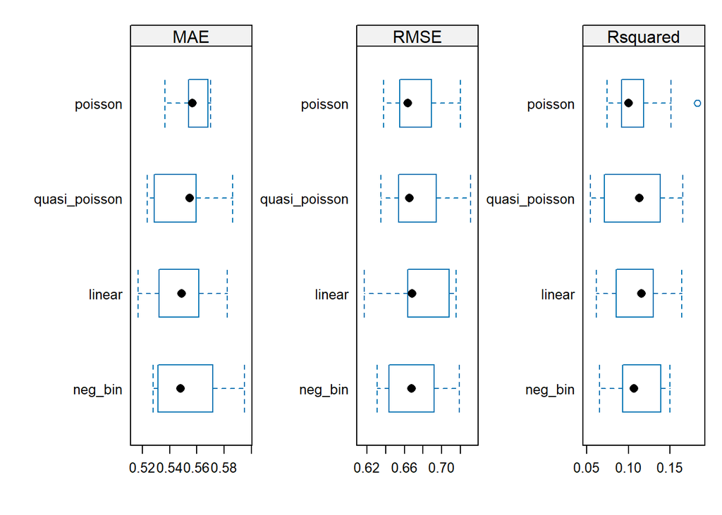

```r
bwplot(results_p, scales = list(x=list(relation="free"), y=list(relation="free")))
```

All of our models seem to be better than the baseline model (lower error and higher R squared). Although the improvement is small, we have obtained better models with better fit and will help us understand the relationship between the predictors and the response variable and make better predictions.

```r
# Compare models using Achaiche information criteria (AIC)
list(AIC = AIC(lm_fit_pharmacy$finalModel,
               poisson_fit_pharmacy$finalModel,
               quasi_poisson_fit_pharmacy$finalModel,
               neg_bin_fit_pharmacy$finalModel))
```

```
## $AIC
##                                       df      AIC
## lm_fit_pharmacy$finalModel            48 7204.535
## poisson_fit_pharmacy$finalModel       48 7034.369
## quasi_poisson_fit_pharmacy$finalModel 48       NA
## neg_bin_fit_pharmacy$finalModel       49 7031.115
```

```r
#Predict on testData
test_res_p <- testData_p %>% mutate(
  pred_lm = predict(lm_fit_pharmacy, testData_p),
  pred_poisson = predict(poisson_fit_pharmacy, testData_p),
  pred_quasipoisson = predict(quasi_poisson_fit_pharmacy, testData_p),
  pred_neg_bin = predict(neg_bin_fit_pharmacy, testData_p)
)

#Compare model performance on testData
post_test_performance <- function(pred_df, tar) {
  df <- data.frame(
  model = c("lm", "poisson", "quasi_poisson", "neg_bin"),
  MAE = c(
    MAE(pred_df$pred_lm, tar),
    MAE(pred_df$pred_poisson, tar),
    MAE(pred_df$pred_quasipoisson, tar),
    MAE(pred_df$pred_quasipoisson, tar)
  ),
  RMSE = c(
    RMSE(pred_df$pred_lm, tar),
    RMSE(pred_df$pred_poisson, tar),
    RMSE(pred_df$pred_quasipoisson, tar),
    RMSE(pred_df$pred_quasipoisson, tar)
  ),
  R2 = c(
    R2(pred_df$pred_lm, tar),
    R2(pred_df$pred_poisson, tar),
    R2(pred_df$pred_quasipoisson, tar),
    R2(pred_df$pred_quasipoisson, tar)
  ))
  return(df)
  }
ptp_p <- post_test_performance(test_res_p, test_res_p$n_pharmacies)
ptp_p
```

```
##           model       MAE      RMSE        R2
## 1            lm 0.5536105 0.6600657 0.1097655
## 2       poisson 0.5653299 0.6619559 0.1053402
## 3 quasi_poisson 0.5536642 0.6602271 0.1093790
## 4       neg_bin 0.5536642 0.6602271 0.1093790
```

```r
ptp_p %>%
  cbind(
    MAE_train = c(mean(lm_fit_pharmacy$resample$MAE),
                  mean(poisson_fit_pharmacy$resample$MAE),
                  mean(quasi_poisson_fit_pharmacy$resample$MAE),
                  mean(neg_bin_fit_pharmacy$resample$MAE)),
    RMSE_train = c(mean(lm_fit_pharmacy$resample$RMSE),
                  mean(poisson_fit_pharmacy$resample$RMSE),
                  mean(quasi_poisson_fit_pharmacy$resample$RMSE),
                  mean(neg_bin_fit_pharmacy$resample$RMSE)),
    R2_train = c(mean(lm_fit_pharmacy$resample$Rsquared),
                  mean(poisson_fit_pharmacy$resample$Rsquared),
                  mean(quasi_poisson_fit_pharmacy$resample$Rsquared),
                  mean(neg_bin_fit_pharmacy$resample$Rsquared))
  ) %>%
  mutate(
    MAE_diff = MAE_train - MAE,
    RMSE_diff = RMSE_train - RMSE,
    R2_diff = R2_train - R2
  ) %>%
  select(model, contains("diff"))
```

```
##           model     MAE_diff  RMSE_diff     R2_diff
## 1            lm -0.004800505 0.01208631 0.002792463
## 2       poisson -0.007038383 0.01158582 0.005281736
## 3 quasi_poisson -0.003203444 0.01396775 0.001390954
## 4       neg_bin -0.000148770 0.01154661 0.003412577
```

We acknowledge that these models are still not the best models to our data and there are other models that could perform better. The zero-inflated poisson could be a good model since our target variable has a lot of 0 observations. However, the caret package currently does not support it so we will not use it in this analysis.

### School

```r
set.seed(100507500)

#Linear Model
lm_fit_school <- train(n_schools ~ ., data = trainData_s,
                method = "lm",
                trControl = train_control)

#Poisson model
poisson_fit_school <- train(n_schools ~ ., data = trainData_s,
                              method = "glm", family = "poisson",
                              trControl = train_control)

#Quasi-Poisson
quasi_poisson_fit_school <- train(n_schools ~ ., data = trainData_s,
                              method = "glm", family = "quasi",
                              trControl = train_control)

#Negative Binomial model
neg_bin_fit_school <- train(n_schools ~ ., data = trainData_s,
                              method = "glm.nb",
                              trControl = train_control)
```

```r
#Compare model performance on trainData
results_s <- resamples(list(linear = lm_fit_school,
                          poisson = poisson_fit_school,
                          quasi_poisson = quasi_poisson_fit_school,
                          neg_bin = neg_bin_fit_school))
summary(results_s)
```

```
##
## Call:
## summary.resamples(object = results_s)
##
## Models: linear, poisson, quasi_poisson, neg_bin
## Number of resamples: 10
##
## MAE
##                    Min.   1st Qu.    Median      Mean   3rd Qu.      Max. NA's
## linear        0.7205667 0.7866389 0.8221214 0.8167008 0.8517035 0.8875801    0
## poisson       0.7678831 0.7911491 0.8003009 0.8062882 0.8105996 0.8822904    0
## quasi_poisson 0.7598585 0.7995690 0.8172902 0.8160395 0.8258761 0.8908261    0
## neg_bin       0.7646241 0.7828537 0.8163829 0.8079484 0.8274242 0.8457366    0
##
## RMSE
##                    Min.  1st Qu.   Median     Mean  3rd Qu.     Max. NA's
## linear        0.9964743 1.105259 1.161120 1.185164 1.246258 1.379445    0
## poisson       1.0867122 1.103956 1.136336 1.158504 1.169992 1.378913    0
## quasi_poisson 1.0724432 1.134093 1.178465 1.181597 1.189635 1.408956    0
## neg_bin       1.0927548 1.137232 1.157588 1.167332 1.204969 1.243241    0
##
## Rsquared
##                    Min.   1st Qu.    Median      Mean   3rd Qu.      Max. NA's
## linear        0.1542386 0.2112299 0.2609309 0.2540474 0.3033104 0.3234358    0
## poisson       0.1882316 0.2619590 0.3103583 0.2836360 0.3226360 0.3305007    0
## quasi_poisson 0.1987012 0.2263011 0.2563354 0.2580550 0.2886359 0.3252392    0
## neg_bin       0.2017973 0.2260385 0.2956757 0.2736707 0.3026532 0.3314100    0
```

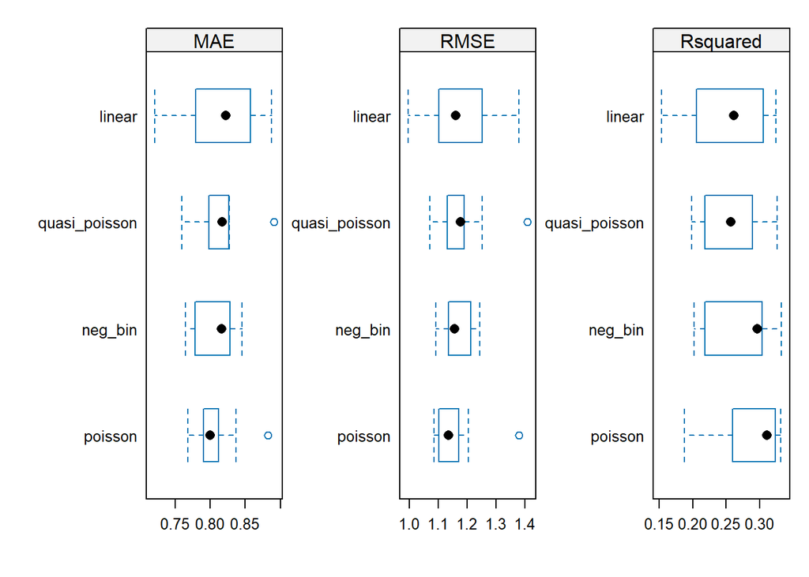

```r
bwplot(results_s, scales = list(x=list(relation="free"), y=list(relation="free")))
```

```r
# Compare models using Achaiche information criteria (AIC)
list(AIC = AIC(lm_fit_school$finalModel,
               poisson_fit_school$finalModel,
               quasi_poisson_fit_school$finalModel,
               neg_bin_fit_school$finalModel))
```

```
## $AIC
##                                     df       AIC
## lm_fit_school$finalModel            39 11146.409
## poisson_fit_school$finalModel       38  8357.592
## quasi_poisson_fit_school$finalModel 38        NA
## neg_bin_fit_school$finalModel       39  8230.516
```

```r
test_res_s <- testData_s %>% mutate(
  pred_lm = predict(lm_fit_school, testData_s),
  pred_poisson = predict(poisson_fit_school, testData_s),
  pred_quasipoisson = predict(quasi_poisson_fit_school, testData_s),
  pred_neg_bin = predict(neg_bin_fit_school, testData_s)
)

ptp_s <- post_test_performance(test_res_s, test_res_s$n_schools)
ptp_s
```

```
##           model       MAE     RMSE        R2
## 1            lm 0.7611266 1.052934 0.2669536
## 2       poisson 0.7581095 1.046660 0.2757238
## 3 quasi_poisson 0.7611266 1.052934 0.2669536
## 4       neg_bin 0.7611266 1.052934 0.2669536
```

```r
ptp_s %>%
  cbind(
    MAE_train = c(mean(lm_fit_school$resample$MAE),
                  mean(poisson_fit_school$resample$MAE),
                  mean(quasi_poisson_fit_school$resample$MAE),
                  mean(neg_bin_fit_school$resample$MAE)),
    RMSE_train = c(mean(lm_fit_school$resample$RMSE),
                   mean(poisson_fit_school$resample$RMSE),
                   mean(quasi_poisson_fit_school$resample$RMSE),
                   mean(neg_bin_fit_school$resample$RMSE)),
    R2_train = c(mean(lm_fit_school$resample$Rsquared),
                 mean(poisson_fit_school$resample$Rsquared),
                 mean(quasi_poisson_fit_school$resample$Rsquared),
                 mean(neg_bin_fit_school$resample$Rsquared))
  ) %>%
  mutate(
    MAE_diff = MAE_train - MAE,
    RMSE_diff = RMSE_train - RMSE,
    R2_diff = R2_train - R2
  ) %>%
  select(model, contains("diff"))
```

```
##           model   MAE_diff RMSE_diff      R2_diff
## 1            lm 0.05557420 0.1322297 -0.012906190
## 2       poisson 0.04817870 0.1118444  0.007912162
## 3 quasi_poisson 0.05491285 0.1286630 -0.008898633
## 4       neg_bin 0.04682183 0.1143984  0.006717089
```

Negative binomial model seems to be the most appropriate model (low error, lowest AIC).

### Transport POS

```r
set.seed(100507500)

#Linear Model
lm_fit_transport <- train(n_transport_salespoints ~ ., data = trainData_t,
                           method = "lm",
                           trControl = train_control)

# Poisson model
poisson_fit_transport <- train(n_transport_salespoints ~ ., data = trainData_t,
                                method = "glm", family = "poisson",
                                trControl = train_control)

# Quasi-Poisson
quasi_poisson_fit_transport <- train(n_transport_salespoints ~ ., data = trainData_t,
                                      method = "glm", family = "quasi",
                                      trControl = train_control)

# Negative Binomial model
neg_bin_fit_transport <- train(n_transport_salespoints ~ ., data = trainData_t,
                               method = "glm.nb",
                               trControl = train_control)
```

```r
#Compare model performance on trainData
results_t <- resamples(list(linear = lm_fit_transport,
                            poisson = poisson_fit_transport,
                            quasi_poisson = quasi_poisson_fit_transport,
                            neg_bin = neg_bin_fit_transport))
summary(results_t)
```

```
##
## Call:
## summary.resamples(object = results_t)
##
## Models: linear, poisson, quasi_poisson, neg_bin
## Number of resamples: 10
##
## MAE
##                    Min.   1st Qu.    Median      Mean   3rd Qu.      Max. NA's
## linear        0.3327636 0.3578842 0.3782767 0.3741762 0.3863958 0.4166310    0
## poisson       0.3472725 0.3554823 0.3615530 0.7995148 0.3695243 4.7133158    0
## quasi_poisson 0.3534937 0.3605930 0.3728885 0.3735212 0.3817402 0.3987931    0
## neg_bin       0.3480845 0.3643065 0.3647869 0.3672183 0.3685897 0.3903238    5
##
## RMSE
##                    Min.   1st Qu.    Median      Mean   3rd Qu.       Max. NA's
## linear        0.4450631 0.4723236 0.4997818 0.5015716 0.5197885  0.5771112    0
## poisson       0.4536974 0.4772322 0.4956457 8.5893480 0.5077461 81.4387280    0
## quasi_poisson 0.4623175 0.4754376 0.4975749 0.4997175 0.5099867  0.5591375    0
## neg_bin       0.4702179 0.4938940 0.5082599 0.5160854 0.5524533  0.5556022    5
##
## Rsquared
##                      Min.    1st Qu.     Median       Mean   3rd Qu.      Max.
## linear        0.055920124 0.06091079 0.09425060 0.09319407 0.1178591 0.1476199
## poisson       0.004598382 0.05531806 0.09994139 0.09421441 0.1347524 0.1809993
## quasi_poisson 0.045984247 0.08491807 0.10408000 0.09912622 0.1171407 0.1507418
## neg_bin       0.057409331 0.08343911 0.08765121 0.10359147 0.1305606 0.1588971
##               NA's
## linear           0
## poisson          0
## quasi_poisson    0
## neg_bin          5
```

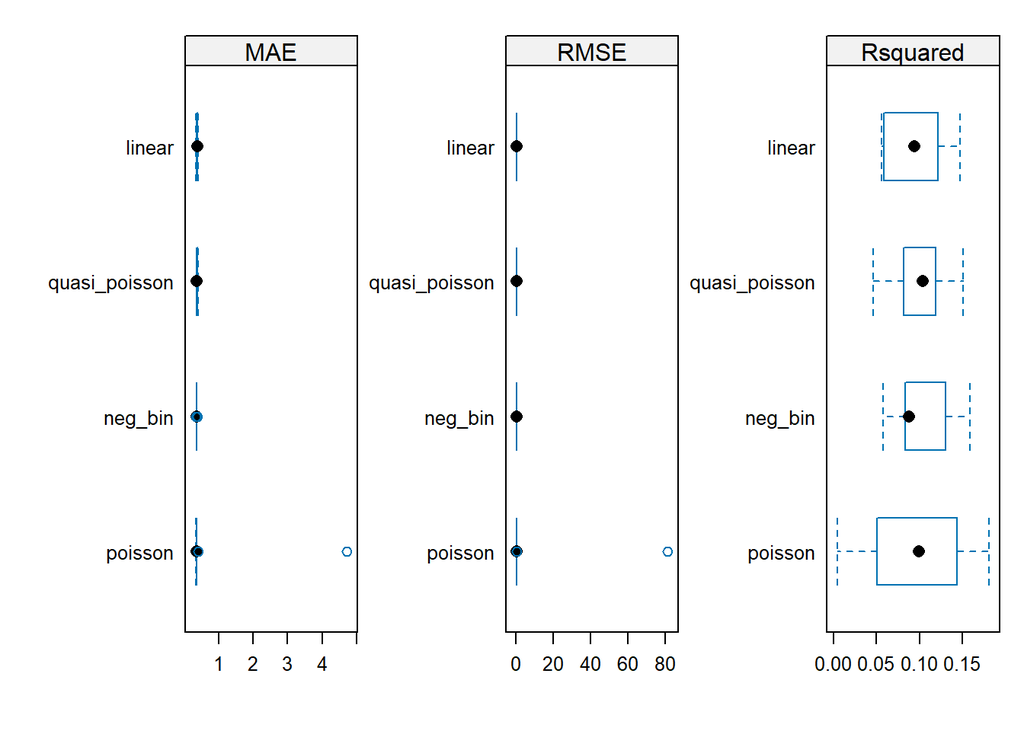

```r
bwplot(results_t, scales = list(x = list(relation = "free"), y = list(relation = "free")))
```

The range of RMSE and MAE of poisson model are strangely high, indicating it might not be an appropriate model. We will not consider it.

```r
#Compare model performance on trainData
results_t <- resamples(list(linear = lm_fit_transport,
                            quasi_poisson = quasi_poisson_fit_transport,
                            neg_bin = neg_bin_fit_transport))
summary(results_t)
```

```
##
## Call:
## summary.resamples(object = results_t)
##
## Models: linear, quasi_poisson, neg_bin
## Number of resamples: 10
##
## MAE
##                    Min.   1st Qu.    Median      Mean   3rd Qu.      Max. NA's
## linear        0.3327636 0.3578842 0.3782767 0.3741762 0.3863958 0.4166310    0
## quasi_poisson 0.3534937 0.3605930 0.3728885 0.3735212 0.3817402 0.3987931    0
## neg_bin       0.3480845 0.3643065 0.3647869 0.3672183 0.3685897 0.3903238    5
##
## RMSE
##                    Min.   1st Qu.    Median      Mean   3rd Qu.      Max. NA's
## linear        0.4450631 0.4723236 0.4997818 0.5015716 0.5197885 0.5771112    0
## quasi_poisson 0.4623175 0.4754376 0.4975749 0.4997175 0.5099867 0.5591375    0
## neg_bin       0.4702179 0.4938940 0.5082599 0.5160854 0.5524533 0.5556022    5
##
## Rsquared
##                     Min.    1st Qu.     Median       Mean   3rd Qu.      Max.
## linear        0.05592012 0.06091079 0.09425060 0.09319407 0.1178591 0.1476199
## quasi_poisson 0.04598425 0.08491807 0.10408000 0.09912622 0.1171407 0.1507418
## neg_bin       0.05740933 0.08343911 0.08765121 0.10359147 0.1305606 0.1588971
##               NA's
## linear           0
## quasi_poisson    0
## neg_bin          5
```

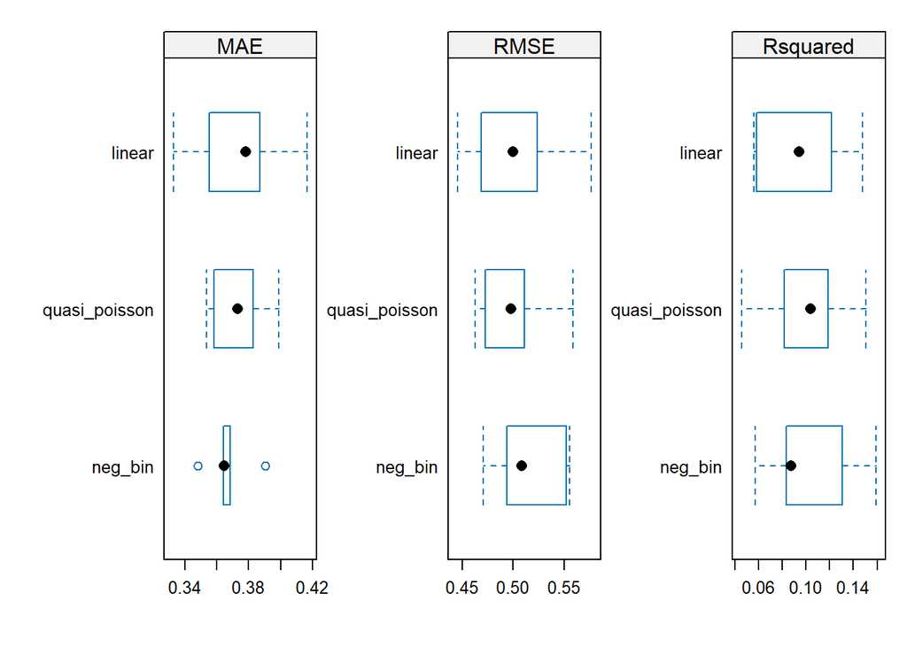

```r
bwplot(results_t, scales = list(x = list(relation = "free"), y = list(relation = "free")))
```

```r
# Compare models using Achaiche information criteria (AIC)
list(AIC = AIC(lm_fit_transport$finalModel,
               poisson_fit_transport$finalModel,
               quasi_poisson_fit_transport$finalModel,
               neg_bin_fit_transport$finalModel))
```

```
## $AIC
##                                        df      AIC
## lm_fit_transport$finalModel            61 5087.869
## poisson_fit_transport$finalModel       61 4272.469
## quasi_poisson_fit_transport$finalModel 61       NA
## neg_bin_fit_transport$finalModel       62 4265.537
```

```r
test_res_t <- testData_t %>% mutate(
  pred_lm = predict(lm_fit_transport, testData_t),
  pred_poisson = predict(poisson_fit_transport, testData_t),
  pred_quasipoisson = predict(quasi_poisson_fit_transport, testData_t),
  pred_neg_bin = predict(neg_bin_fit_transport, testData_t)
)

ptp_t <- post_test_performance(test_res_t, test_res_t$n_transport_salespoints)
ptp_t
```

```
##           model       MAE      RMSE         R2
## 1            lm 0.3536232 0.4548283 0.09703516
## 2       poisson 0.3480907 0.4562450 0.09289728
## 3 quasi_poisson 0.3537312 0.4550261 0.09650426
## 4       neg_bin 0.3537312 0.4550261 0.09650426
```

```r
ptp_t %>%
  cbind(
    MAE_train = c(mean(lm_fit_transport$resample$MAE),
                  mean(poisson_fit_transport$resample$MAE),
                  mean(quasi_poisson_fit_transport$resample$MAE),
                  mean(neg_bin_fit_transport$resample$MAE, na.rm=T)),
    RMSE_train = c(mean(lm_fit_transport$resample$RMSE),
                   mean(poisson_fit_transport$resample$RMSE),
                   mean(quasi_poisson_fit_transport$resample$RMSE),
                   mean(neg_bin_fit_transport$resample$RMSE, na.rm=T)),
    R2_train = c(mean(lm_fit_transport$resample$Rsquared),
                 mean(poisson_fit_transport$resample$Rsquared),
                 mean(quasi_poisson_fit_transport$resample$Rsquared),
                 mean(neg_bin_fit_transport$resample$Rsquared, na.rm=T))
  ) %>%
  mutate(
    MAE_diff = MAE_train - MAE,
    RMSE_diff = RMSE_train - RMSE,
    R2_diff = R2_train - R2
  ) %>%
  select(model, contains("diff"))
```

```
##           model   MAE_diff  RMSE_diff      R2_diff
## 1            lm 0.02055299 0.04674335 -0.003841081
## 2       poisson 0.45142412 8.13310296  0.001317125
## 3 quasi_poisson 0.01979008 0.04469134  0.002621966
## 4       neg_bin 0.01348711 0.06105931  0.007087212
```

Quasi-poisson or Negative Binomial seems to be an apt model. Since we ran into problems while training the Negative Binomial (some folds have NAs) we will use quasi-poisson instead.

## Score generation

```r
#Train on whole data set
#Pharmacy
finalModel_p <- train(n_pharmacies ~ ., data = fe_p,
                              method = "glm", family = "quasi",
                              trControl = train_control)
#School
finalModel_s <- train(n_schools ~ ., data = fe_s,
                              method = "glm.nb",
                              trControl = train_control)
#Transport
finalModel_t <- train(n_transport_salespoints ~ ., data = fe_t,
                                      method = "glm", family = "quasi",
                                      trControl = train_control)
```

```r
#Final predictions
finalPred_p <- predict(finalModel_p, fe_p) %>% as.vector()
finalPred_s <- predict(finalModel_s, fe_s) %>% as.vector()
finalPred_t <- predict(finalModel_t, fe_t) %>% as.vector()
```

```r
#Score generation
score_df <- df_num %>%
  mutate(score_pharmacy = floor(finalPred_p),
         score_school = floor(finalPred_s),
         score_transport = floor(finalPred_t),
         lack_facilities = ifelse(score_pharmacy > n_pharmacies|
                                    score_school > n_schools |
                                    score_transport > n_transport_salespoints,
                                  "Yes",
                                  "No")) %>%
  mutate(lack_facilities = as.factor(lack_facilities))
```

```r
#Split data
set.seed(100507500)

fs <- score_df %>% select(-contains("n_"), -contains("score_"))

toTrain_C <- createDataPartition(fs$lack_facilities, p =0.8, list=F)

trainData <- fs[toTrain_C,]
testData <- fs[-toTrain_C,]
```

```r
logReg <- train(lack_facilities ~., data = trainData,
                method = "glm", family = "binomial",
                trControl = train_control)

#Predictions
pred <- predict(logReg, testData, type = "prob")
predClass <- ifelse(pred$Yes > 0.3, "Yes", "No") %>% as.factor()
# Model accuracy
mean(predClass == testData$lack_facilities)
```

```
## [1] 0.8174603
```

We want to increase sensitivity for the model since we want to be able to predict censuses that are actually lacking the facilities so we use 0.3 for the threshold.

```r
confusionMatrix(testData$lack_facilities, predClass, positive = "Yes")
```

```
## Confusion Matrix and Statistics
##
##           Reference
## Prediction  No Yes
##        No  682  72
##        Yes  89  39
##
##                Accuracy : 0.8175
##                  95% CI : (0.7904, 0.8424)
##     No Information Rate : 0.8741
##     P-Value [Acc > NIR] : 1.0000
##
##                   Kappa : 0.2214
##
##  Mcnemar's Test P-Value : 0.2073
##
##             Sensitivity : 0.35135
##             Specificity : 0.88457
##          Pos Pred Value : 0.30469
##          Neg Pred Value : 0.90451
##              Prevalence : 0.12585
##          Detection Rate : 0.04422
##    Detection Prevalence : 0.14512
##       Balanced Accuracy : 0.61796
##
##        'Positive' Class : Yes
##
```

```r
getTrainPerf(logReg)
```

```
##   TrainAccuracy TrainKappa method
## 1     0.8524965 0.05520148    glm
```

```r
roc(testData$lack_facilities, factor(predClass, ordered = T))
```

```
##
## Call:
## roc.default(response = testData$lack_facilities, predictor = factor(predClass,     ordered = T))
##
## Data: factor(predClass, ordered = T) in 754 controls (testData$lack_facilities No) < 128 cases (testData$lack_facilities Yes).
## Area under the curve: 0.6046
```

Although the AUC is only moderate, indicating this might not be the best model but we will use it for this problem.

```r
#Train on all data
set.seed(100507500)
logReg_final <- train(lack_facilities ~., data = fs,
                method = "glm", family = "binomial",
                trControl = train_control)

summary(logReg_final)
```

```
##
## Call:
## NULL
##
## Deviance Residuals:
##     Min       1Q   Median       3Q      Max
## -1.7832  -0.6034  -0.4079  -0.2495   2.9959
##
## Coefficients: (1 not defined because of singularities)
##                      Estimate Std. Error z value Pr(>|z|)
## (Intercept)        -2.472e+06  2.946e+06  -0.839   0.4013
## area                8.853e-03  4.897e-03   1.808   0.0707 .
## lat                -2.095e-06  4.743e-06  -0.442   0.6588
## long               -1.307e-05  5.602e-06  -2.333   0.0196 *
## population          6.235e-04  1.002e-04   6.222  4.9e-10 ***
## family_income       1.821e-06  1.515e-05   0.120   0.9043
## income_per_capita   4.363e-05  4.275e-05   1.021   0.3074
## avg_age             3.776e-01  1.710e-01   2.208   0.0272 *
## spanish             1.561e+06  2.803e+06   0.557   0.5776
## foreigners          1.561e+06  2.803e+06   0.557   0.5776
## europeans          -3.223e+01  3.604e+01  -0.894   0.3712
## germans             4.114e+01  4.037e+01   1.019   0.3082
## bulgarian           4.462e+01  2.745e+01   1.625   0.1041
## french              2.926e+01  2.927e+01   1.000   0.3175
## italian             4.169e+01  3.027e+01   1.377   0.1684
## polish              4.466e+00  3.260e+01   0.137   0.8911
## portuguese          3.164e+01  3.364e+01   0.941   0.3469
## british             3.982e+01  4.115e+01   0.968   0.3332
## romanian            1.878e+01  2.576e+01   0.729   0.4659
## russian            -7.577e+00  5.244e+01  -0.144   0.8851
## ukranian           -3.556e+01  2.870e+01  -1.239   0.2154
## african             6.019e+00  2.909e+01   0.207   0.8361
## algerian           -5.325e+01  6.826e+01  -0.780   0.4353
## moroccan           -1.147e+01  1.552e+01  -0.739   0.4599
## nigerian           -8.118e+01  3.264e+01  -2.487   0.0129 *
## senegalese         -2.993e+01  4.194e+01  -0.714   0.4754
## american           -2.419e+00  2.582e+01  -0.094   0.9253
## argentinian        -1.205e+01  3.380e+01  -0.356   0.7216
## bolivian           -5.549e+00  1.524e+01  -0.364   0.7158
## brazilian           7.398e+00  2.175e+01   0.340   0.7338
```

[output cut: 19 more lines]

```
## pcg_expense_home   -5.725e-03  3.240e-03  -1.767   0.0772 .
## ratio_expense_home -2.972e-02  1.479e-02  -2.009   0.0445 *
## altitude            1.009e-03  9.375e-04   1.076   0.2819
## city_population    -1.087e-08  4.828e-08  -0.225   0.8219
## pcg_foreigners             NA         NA      NA       NA
## ---
## Signif. codes:  0 '***' 0.001 '**' 0.01 '*' 0.05 '.' 0.1 ' ' 1
##
## (Dispersion parameter for binomial family taken to be 1)
##
##     Null deviance: 3661.2  on 4413  degrees of freedom
## Residual deviance: 3215.5  on 4361  degrees of freedom
## AIC: 3321.5
##
## Number of Fisher Scoring iterations: 6
```

```r
#Sorted list of sum of absolute coefficients of variables
varImp(logReg_final, scale = F)
```

```
## glm variable importance
##
##   only 20 most important variables shown (out of 52)
##
##                    Overall
## population           6.222
## paraguayan           3.090
## nigerian             2.487
## pakistani            2.440
## ecuadorian           2.435
## long                 2.333
## avg_age              2.208
## ratio_expense_home   2.009
## peruvian             1.954
## area                 1.808
## pcg_expense_home     1.767
## chininese            1.639
## bulgarian            1.625
## italian              1.377
## dominican            1.374
## venezuelan           1.261
## ukranian             1.239
## altitude             1.076
## cuban                1.047
## income_per_capita    1.021
```

```r
predClassFinal <- predict(logReg_final, df, type = "raw")

df_final <- df %>%
  mutate(lack_facilities_pred = predClassFinal)
```

# Result analysis and visualization

From the descriptive analysis, we see that our target variables are not evenly distributed throughout the censuses. Some censuses have 0 facilities while some area have an excessive amount compared to the average. This could have been due to the distribution in population as some areas are more populated and therfore might need more facilities.

We then conducted that correlation analysis and learned that some variables correlated to each other so multicolinearity was a potential issue and we would need to remove some variables in order to enhance the model’s performance. We also did a zero variance analysis to check for variables with low to 0 variance so we could eliminate them from the data set since they would not offer any useful information to the model.

We selected the features after removing the duplicated and low variance variables, then further reduced the dimension of the data set using an ElasticNet model. In our case, the selected model had an alpha = 1 so the model is essentially a Lasso Regression model. For each of the target variable, we obtained different dimension reduction results and we created 3 different data frames for each of the target variable according to these results.

After training different models and compared their performance on train set and test set, we saw that they were not exactly the most appropriate models (with low R2 and little improvement on the fitness compared the baseline model). It is probably that our predictors and response variables do not follow a linear relationship, which our models are based on, therefore the models could not perform well. For more accurate results, we should consider other models.

Acknowledging these limitations, we continued with the best models out of the ones that we trained (Quasi-poisson Regression for n_pharmacies and n_transport_salespoints, Negative Binomial Regression for n_schools). Using these models to make prediction on the entire dataset, we obtained a score to decide whether a census lacks facilities (“Yes” for censuses with actual values < predicted values in any of the 3 target variables). Finally, we then trained a Logistic Regression model to classify whether the lack the facilities or not. This helped us find out that the top variables related to the lack of facilities are population and certain percentage of certain nationality groups, along with the area, home expense, average age, and position of the census (longitude). Although, none of them are key indicators with strong influence on whether the census lacks facilities (low aggregated absolute coefficient). We can visualise the top 10 most important variables on a scale from 0 to 100 below.

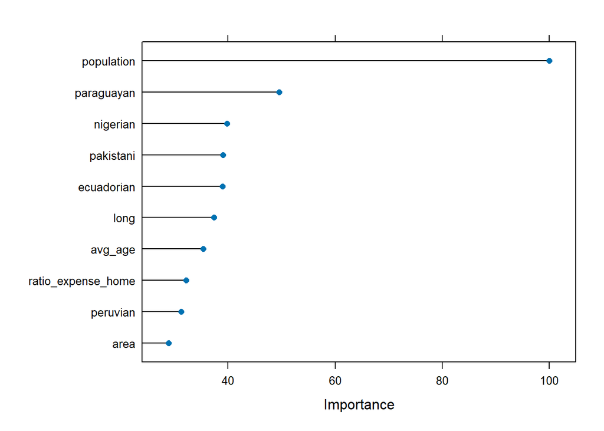

```r
plot(varImp(logReg_final), top = 10)
```

Population seems to be the better indicator than others. This is logical as more bigger population might need more facilities, creating a higher demand. Other nationality variables might also be noteworthy. We can look into whether the censuses with high population of these nationalities do not have sustainable income or isolated from the community, etc. to find solutions that could help them overcome these issues.

It is also noted that the performance of the Logistic Regression model is moderate and there might be more models that could perform better. We can also further divide the censuses to different types (lacking 1 facility, lacking 2 facilities, lacking all 3, or lacking pharmacies, lacking pharmacies and schools, etc.). For this type of problem, we would need to use a model such as multinomial classification to make the predictions.

Using the Logistic Regression model, we made final predictions on the original data set to obtain an estimate of which censuses are in need of more facilities. Although the number is relatively small, these facilities are essential and hence should be adequately provided to all censuses. Below is a map showing censuses that might be lacking facilities.

```r
library(sf)
```

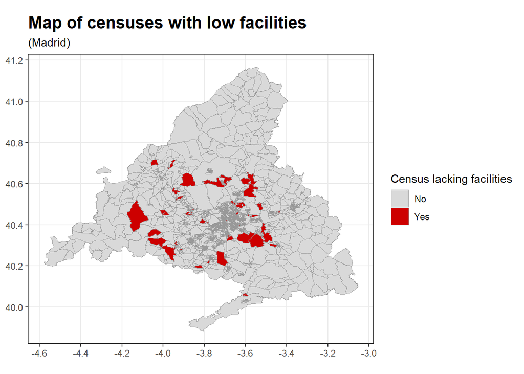

```r
map <- st_as_sf(df_final, wkt = "geometry")

ggplot(data = map) +
  geom_sf(aes(fill = lack_facilities_pred),
          lwd = 0.2,
          color = "grey60") +
  scale_fill_manual(values = c("grey85", "red3")) +
  labs(
    fill = "Census lacking facilities",
    title = "Map of censuses with low facilities",
    subtitle = "(Madrid)"
  ) +
  theme_bw() +
  theme(
    plot.title = element_text(size = 16, face = "bold")
  )
```

In order to improve the access to facilities, we can further analyse the data of these censuses with close attention to the variables mentioned above.